# Neural Networks

# Read MNIST Data

You must read the data before trying to run code on your own machine. To read data use the following code after setting your working directory. To set your working directory, modify the following to set the file path for the folder where the data file resides. setwd(’c:/thatawesomeclass/neuralnetworks/)

```r
digits = read.csv('train_m10.csv')
```

# Explore Data

```r
dim(digits)
```

```
## [1] 42000   785
```

```r
head(colnames(digits))
```

```
## [1] "label"  "pixel0" "pixel1" "pixel2" "pixel3" "pixel4"
```

```r
tail(colnames(digits))
```

```
## [1] "pixel778" "pixel779" "pixel780" "pixel781" "pixel782" "pixel783"
```

```r
head(digits[1:5,1:5])
```

| label | pixel0 | pixel1 | pixel2 | pixel3 |
| --- | --- | --- | --- | --- |
| 1 | 0 | 0 | 0 | 0 |
| 0 | 0 | 0 | 0 | 0 |
| 1 | 0 | 0 | 0 | 0 |
| 4 | 0 | 0 | 0 | 0 |
| 0 | 0 | 0 | 0 | 0 |

```r
digits$label[1:100]
```

```
##   [1] 1 0 1 4 0 0 7 3 5 3 8 9 1 3 3 1 2 0 7 5 8 6 2 0 2 3 6 9 9 7 8 9 4 9 2 1 3
##  [38] 1 1 4 9 1 4 4 2 6 3 7 7 4 7 5 1 9 0 2 2 3 9 1 1 1 5 0 6 3 4 8 1 0 3 9 6 2
##  [75] 6 4 7 1 4 1 5 4 8 9 2 9 9 8 9 6 3 6 4 6 2 9 1 2 0 5
```

# Prepare Data

```r
digits$label = factor(digits$label,levels = 0:9)
set.seed(1031)
split = sample(x = c('train','validation','test'),size = nrow(digits),
               replace = T,prob = c(0.4,0.4,0.2))
train = digits[split=='train',]
validation = digits[split=='validation',]
test = digits[split=='test',]
```

## See Digits

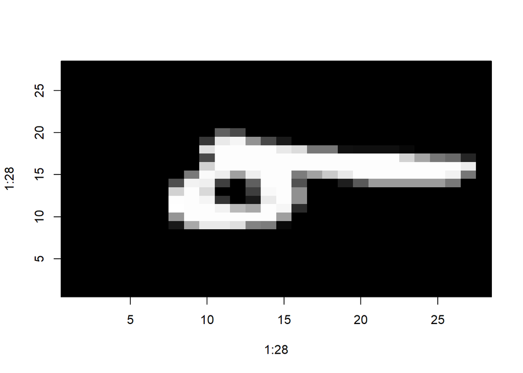

```r
viewDigit = function(num,flip=F){
  img = matrix(as.numeric(train[num,2:785]),ncol=28,byrow = flip)
  return(image(x = 1:28,y = 1:28,z = img,col=gray((0:255)/255)))
}
viewDigit(101,flip = T)
```

# Basic Neural Network

Hidden Layer(s): 1  
Hidden Units or Neurons: 5  
Using library(nnet).  
For more on library(nnet) see the [documentation](https://cran.r-project.org/web/packages/nnet/nnet.pdf)

```r
library(nnet)
set.seed(1031)
model1 = nnet(label~.,
             data = train,
             size=5,
             decay=0.1,
             MaxNWts=10000,
             maxit=100)
```

## Performance on Train sample

```r
pred_train_prob = predict(model1)
pred_train_prob[1,]
```

```
##            0            1            2            3            4            5
## 4.334108e-09 9.533198e-01 1.787669e-02 1.376767e-02 3.512015e-07 7.769479e-03
##            6            7            8            9
## 5.957880e-11 2.652715e-04 6.894980e-03 1.057805e-04
```

```r
sum(pred_train_prob[1,])
```

```
## [1] 1
```

```r
pred_train = predict(model1,type='class')
train$label[1]
```

```
## [1] 1
## Levels: 0 1 2 3 4 5 6 7 8 9
```

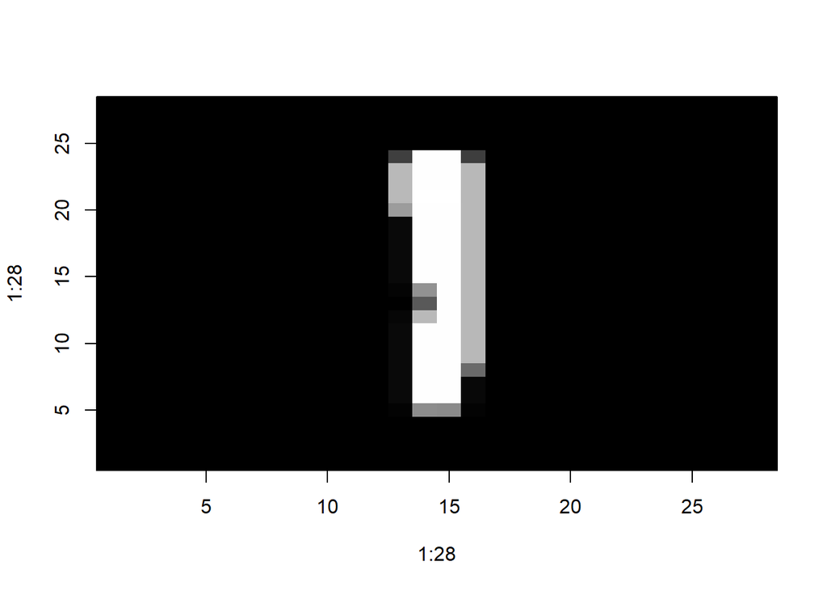

```r
viewDigit(1)
```

```r
pred_train[1]
```

```
## [1] "1"
```

```r
table(train$label,pred_train)
```

```
##    pred_train
##        0    1    2    3    4    5    6    7    8    9
##   0 1312    3  163    6    3   36  112    0    2    5
##   1    3 1767   23   13    1   14    4   18   13    5
##   2  106  260 1000   39    8   30   88   22   26   57
##   3   16   61   34  901   31  533   46   25   36   68
##   4    2    7   35    2  608   15   19   35   10  908
##   5   13  115   46   41  113  971   80    5  124   62
##   6   51    7  193    7   35   89 1243    0   10   19
##   7    1   49   27   10   24   17    0 1433    4  161
##   8    3  170   77   50    6  346   49   10  865   73
##   9    2    7   36   17  334   18   15  212   17 1026
```

```r
mean(pred_train==train$label) # Accuracy
```

```
## [1] 0.6617105
```

## Performance on Validation sample

```r
pred = predict(model1,newdata=validation,type='class')
table(validation$label,pred)
```

```
##    pred
##        0    1    2    3    4    5    6    7    8    9
##   0 1345    3  148    1    4   35  131    0    9    6
##   1    1 1817   20   22    0   18    1   18   20    2
##   2   96  256 1089   44    9   35   83   16   30   62
##   3   22   62   40  853   33  540   46   27   31   60
##   4    3    7   37    2  593    6   22   31    7  913
##   5   19  119   57   45  128  881   56    6  124   68
##   6   62    8  223    3   36  106 1229    0    6   17
##   7    1   49   32   14   24   22    4 1458    7  179
##   8    2  196   63   51   17  341   48    9  801   67
##   9    4    9   34   21  330   35   13  222   15  973
```

```r
mean(pred == validation$label)
```

```
## [1] 0.653582
```

## Performance on Test sample

```r
pred = predict(model1,newdata=test,type='class')
table(test$label,pred)
```

```
##    pred
##       0   1   2   3   4   5   6   7   8   9
##   0 646   3  74   4   1  18  56   0   2   4
##   1   2 853  18   6   1  10   0   7   5   2
##   2  50 143 499  19   6  14  43   9  11  27
##   3   9  41  14 442  15 270  22  16  18  39
##   4   3   3  16   3 264   4  11  18   8 480
##   5  11  63  22  20  55 444  26   2  61  18
##   6  24   5  96   3   9  46 591   1   4  14
##   7   0  21  12   7  15   2   4 739   2  83
##   8   0 110  31  23   3 169  17   2 420  44
##   9   1   3  19  14 158  14   1 109   7 522
```

```r
mean(pred == test$label)
```

```
## [1] 0.6533269
```

```r
library(caret); confusionMatrix(factor(pred),test$label)
```

```
## Confusion Matrix and Statistics
##
##           Reference
## Prediction   0   1   2   3   4   5   6   7   8   9
##          0 646   2  50   9   3  11  24   0   0   1
##          1   3 853 143  41   3  63   5  21 110   3
##          2  74  18 499  14  16  22  96  12  31  19
##          3   4   6  19 442   3  20   3   7  23  14
##          4   1   1   6  15 264  55   9  15   3 158
##          5  18  10  14 270   4 444  46   2 169  14
##          6  56   0  43  22  11  26 591   4  17   1
##          7   0   7   9  16  18   2   1 739   2 109
##          8   2   5  11  18   8  61   4   2 420   7
##          9   4   2  27  39 480  18  14  83  44 522
##
## Overall Statistics
##
##                Accuracy : 0.6533
##                  95% CI : (0.643, 0.6636)
##     No Information Rate : 0.109
##     P-Value [Acc > NIR] : < 2.2e-16
##
##                   Kappa : 0.6147
##
##  Mcnemar's Test P-Value : NA
##
## Statistics by Class:
##
##                      Class: 0 Class: 1 Class: 2 Class: 3 Class: 4 Class: 5
## Sensitivity           0.79950   0.9436  0.60780  0.49887  0.32593  0.61496
## Specificity           0.98665   0.9470  0.95960  0.98664  0.96487  0.92778
## Pos Pred Value        0.86595   0.6851  0.62297  0.81701  0.50095  0.44803
## Neg Pred Value        0.97854   0.9928  0.95704  0.94275  0.92972  0.96194
## Prevalence            0.09740   0.1090  0.09896  0.10680  0.09764  0.08703
## Detection Rate        0.07787   0.1028  0.06015  0.05328  0.03182  0.05352
## Detection Prevalence  0.08992   0.1501  0.09655  0.06521  0.06352  0.11946
## Balanced Accuracy     0.89308   0.9453  0.78370  0.74276  0.64540  0.77137
##                      Class: 6 Class: 7 Class: 8 Class: 9
## Sensitivity           0.74527  0.83503  0.51282  0.61557
## Specificity           0.97601  0.97787  0.98422  0.90454
## Pos Pred Value        0.76654  0.81838  0.78067  0.42336
## Neg Pred Value        0.97316  0.98025  0.94857  0.95384
## Prevalence            0.09559  0.10668  0.09872  0.10222
## Detection Rate        0.07124  0.08908  0.05063  0.06292
## Detection Prevalence  0.09294  0.10885  0.06485  0.14863
## Balanced Accuracy     0.86064  0.90645  0.74852  0.76005
```

## Digits that Model got wrong

```r
# Digits that the model got wrong
which(pred!=test$label)
```

```
##    [1]    7   11   13   15   16   17   18   20   21   23   26   27   31   33
##   [15]   34   35   39   41   45   47   52   54   63   70   73   74   76   80
##   [29]   81   84   85   91   92  101  102  108  110  113  115  117  121  123
##   [43]  125  126  130  132  134  135  137  145  147  151  157  158  162  170
##   [57]  171  172  175  185  186  192  193  197  199  204  205  206  207  209
##   [71]  210  211  212  219  222  223  228  235  236  237  242  244  248  254
##   [85]  256  259  261  263  267  274  275  278  289  293  297  300  301  303
##   [99]  308  310  317  321  324  325  329  333  338  345  348  350  355  358
##  [113]  359  360  361  362  364  367  370  372  374  377  387  388  392  393
##  [127]  398  400  405  406  408  411  421  423  425  427  428  429  431  433
##  [141]  435  442  446  449  451  453  454  458  459  460  467  472  479  481
##  [155]  482  487  489  492  494  498  507  508  517  519  523  525  526  529
##  [169]  530  533  537  544  546  547  551  553  555  556  557  559  560  563
##  [183]  564  566  567  570  572  573  575  576  578  579  580  583  586  590
##  [197]  592  593  595  598  601  602  608  612  614  616  617  620  621  628
```

[output cut: 191 more lines]

[figure not shown]

```r
# Examine the second digit the model got wrong
viewDigit(11)
```

# Neural Networks with Multiple Layers

We are going to explore a popular deep learning framework called h2o. For more on this, see the [documentation](https://cran.r-project.org/web/packages/h2o/h2o.pdf). h2o is a powerful package useful for not only deep learning but also machine learning. It is designed for scalability and is more flexible than nnet.

## Convert data to h2o objects

```r
library(h2o)
h2o.init()
```

```
##
## H2O is not running yet, starting it now...
##
## Note:  In case of errors look at the following log files:
##     C:\Users\Kitty\AppData\Local\Temp\Rtmp8SDZ1W\file40907f393c79/h2o_Kitty_started_from_r.out
##     C:\Users\Kitty\AppData\Local\Temp\Rtmp8SDZ1W\file4090575a15af/h2o_Kitty_started_from_r.err
##
##
## Starting H2O JVM and connecting:  Connection successful!
##
## R is connected to the H2O cluster:
##     H2O cluster uptime:         2 seconds 765 milliseconds
##     H2O cluster timezone:       America/New_York
##     H2O data parsing timezone:  UTC
##     H2O cluster version:        3.36.0.3
##     H2O cluster version age:    1 month and 7 days
##     H2O cluster name:           H2O_started_from_R_Kitty_bxn282
##     H2O cluster total nodes:    1
##     H2O cluster total memory:   7.90 GB
##     H2O cluster total cores:    8
##     H2O cluster allowed cores:  8
##     H2O cluster healthy:        TRUE
##     H2O Connection ip:          localhost
##     H2O Connection port:        54321
##     H2O Connection proxy:       NA
##     H2O Internal Security:      FALSE
##     R Version:                  R version 4.1.2 (2021-11-01)
```

```r
train_h2o = as.h2o(train)
validation_h2o = as.h2o(validation)
test_h2o = as.h2o(test)
```

# Single Layer Network with h20

This is simply a replication of the single layer network created before using nnet()  
Hidden Layer: 1  
Hidden Units: 5

```r
model2 = h2o.deeplearning(x=2:785,
                         y = 1,
                         training_frame = train_h2o,
                         hidden = c(5),
                         seed=1031)
```

## Performance on validation sample

```r
pred = h2o.predict(model2,newdata = validation_h2o)
mean(pred[1]==validation_h2o$label) # Accuracy
```

```
## [1] 0.7415038
```

```r
h2o.confusionMatrix(model2,validation_h2o) # Using a built-in function
```

|  | 0 | 1 | 2 | 3 | 4 | 5 | 6 | 7 | 8 | 9 | Error | Rate |
| --- | --- | --- | --- | --- | --- | --- | --- | --- | --- | --- | --- | --- |
| 0 | 1444 | 3 | 142 | 11 | 0 | 44 | 26 | 4 | 7 | 1 | 0.1414982 | 238 / 1,682 |
| 1 | 42 | 1605 | 159 | 9 | 2 | 7 | 1 | 16 | 77 | 1 | 0.1636269 | 314 / 1,919 |
| 2 | 56 | 54 | 1385 | 93 | 5 | 10 | 17 | 47 | 52 | 1 | 0.1947674 | 335 / 1,720 |
| 3 | 5 | 8 | 330 | 1196 | 3 | 46 | 26 | 42 | 45 | 13 | 0.3022170 | 518 / 1,714 |
| 4 | 6 | 1 | 100 | 8 | 1212 | 79 | 1 | 9 | 42 | 163 | 0.2523134 | 409 / 1,621 |
| 5 | 61 | 15 | 373 | 91 | 18 | 800 | 17 | 18 | 15 | 95 | 0.4677312 | 703 / 1,503 |
| 6 | 150 | 15 | 130 | 194 | 1 | 12 | 1132 | 18 | 37 | 1 | 0.3301775 | 558 / 1,690 |
| 7 | 1 | 30 | 41 | 71 | 11 | 77 | 3 | 1464 | 30 | 62 | 0.1821229 | 326 / 1,790 |
| 8 | 77 | 76 | 196 | 60 | 60 | 33 | 29 | 10 | 1016 | 38 | 0.3630094 | 579 / 1,595 |
| 9 | 9 | 2 | 26 | 16 | 131 | 99 | 7 | 66 | 30 | 1270 | 0.2330918 | 386 / 1,656 |
| Totals | 1851 | 1809 | 2882 | 1749 | 1443 | 1207 | 1259 | 1694 | 1351 | 1645 | 0.2584962 | 4,366 / 16,890 |

## Performance on test sample

```r
pred = h2o.predict(model2,newdata = test_h2o)
mean(pred[1]==test_h2o$label) # Accuracy
```

```
## [1] 0.7268563
```

```r
h2o.confusionMatrix(model2,test_h2o) # Using a built-in function
```

|  | 0 | 1 | 2 | 3 | 4 | 5 | 6 | 7 | 8 | 9 | Error | Rate |
| --- | --- | --- | --- | --- | --- | --- | --- | --- | --- | --- | --- | --- |
| 0 | 690 | 4 | 62 | 10 | 0 | 24 | 13 | 3 | 2 | 0 | 0.1460396 | 118 / 808 |
| 1 | 28 | 732 | 93 | 2 | 2 | 5 | 0 | 11 | 31 | 0 | 0.1902655 | 172 / 904 |
| 2 | 23 | 39 | 622 | 56 | 4 | 5 | 4 | 29 | 39 | 0 | 0.2423873 | 199 / 821 |
| 3 | 4 | 6 | 142 | 600 | 4 | 42 | 10 | 35 | 32 | 11 | 0.3227991 | 286 / 886 |
| 4 | 6 | 0 | 46 | 6 | 590 | 43 | 0 | 6 | 28 | 85 | 0.2716049 | 220 / 810 |
| 5 | 35 | 9 | 181 | 49 | 9 | 385 | 6 | 10 | 5 | 33 | 0.4667590 | 337 / 722 |
| 6 | 72 | 11 | 61 | 80 | 2 | 9 | 538 | 11 | 9 | 0 | 0.3215637 | 255 / 793 |
| 7 | 3 | 10 | 22 | 35 | 7 | 31 | 0 | 721 | 20 | 36 | 0.1853107 | 164 / 885 |
| 8 | 52 | 28 | 105 | 31 | 33 | 16 | 11 | 6 | 518 | 19 | 0.3675214 | 301 / 819 |
| 9 | 7 | 2 | 13 | 8 | 79 | 43 | 0 | 49 | 13 | 634 | 0.2523585 | 214 / 848 |
| Totals | 920 | 841 | 1347 | 877 | 730 | 603 | 582 | 881 | 697 | 818 | 0.2731437 | 2,266 / 8,296 |

# Neural Network with Two Hidden Layers

Hidden Layers: 2  
Hidden Units: 5 in each layer

```r
model3 = h2o.deeplearning(x=2:785,
                         y = 1,
                         training_frame = train_h2o,
                         hidden = c(5,5),
                         seed=1031)
```

## Performance on Validation Sample

```r
pred = h2o.predict(model3,validation_h2o)
mean(pred[1]==validation_h2o$label) # Accuracy
```

```
## [1] 0.8309059
```

```r
h2o.confusionMatrix(model3,validation_h2o) # Using a built-in function
```

|  | 0 | 1 | 2 | 3 | 4 | 5 | 6 | 7 | 8 | 9 | Error | Rate |
| --- | --- | --- | --- | --- | --- | --- | --- | --- | --- | --- | --- | --- |
| 0 | 1557 | 2 | 9 | 9 | 1 | 58 | 36 | 5 | 4 | 1 | 0.0743163 | 125 / 1,682 |
| 1 | 4 | 1813 | 7 | 34 | 13 | 7 | 9 | 2 | 23 | 7 | 0.0552371 | 106 / 1,919 |
| 2 | 17 | 36 | 1303 | 171 | 23 | 41 | 13 | 6 | 108 | 2 | 0.2424419 | 417 / 1,720 |
| 3 | 12 | 31 | 167 | 1322 | 7 | 112 | 4 | 47 | 8 | 4 | 0.2287048 | 392 / 1,714 |
| 4 | 2 | 6 | 2 | 18 | 1422 | 16 | 41 | 1 | 34 | 79 | 0.1227637 | 199 / 1,621 |
| 5 | 20 | 5 | 39 | 46 | 36 | 1153 | 57 | 45 | 98 | 4 | 0.2328676 | 350 / 1,503 |
| 6 | 109 | 7 | 3 | 7 | 32 | 57 | 1449 | 0 | 20 | 6 | 0.1426036 | 241 / 1,690 |
| 7 | 5 | 21 | 7 | 106 | 16 | 11 | 4 | 1520 | 6 | 94 | 0.1508380 | 270 / 1,790 |
| 8 | 8 | 62 | 126 | 45 | 41 | 86 | 58 | 7 | 1124 | 38 | 0.2952978 | 471 / 1,595 |
| 9 | 3 | 1 | 0 | 25 | 78 | 24 | 27 | 117 | 10 | 1371 | 0.1721014 | 285 / 1,656 |
| Totals | 1737 | 1984 | 1663 | 1783 | 1669 | 1565 | 1698 | 1750 | 1435 | 1606 | 0.1690941 | 2,856 / 16,890 |

# Neural Network with Three Hidden Layers

Hidden Layers: 3  
Hidden Units: 10 in each layer

```r
model4 = h2o.deeplearning(x=2:785,
                         y = 1,
                         training_frame = train_h2o,
                         hidden = c(10,10,10),
                         seed=1031)
```

## Performance on Validation Sample

```r
pred = h2o.predict(model4,validation_h2o)
mean(pred[1]==validation_h2o$label) # Accuracy
```

```
## [1] 0.9071048
```

```r
h2o.confusionMatrix(model4,validation_h2o)
```

|  | 0 | 1 | 2 | 3 | 4 | 5 | 6 | 7 | 8 | 9 | Error | Rate |
| --- | --- | --- | --- | --- | --- | --- | --- | --- | --- | --- | --- | --- |
| 0 | 1618 | 0 | 11 | 2 | 1 | 27 | 11 | 2 | 10 | 0 | 0.0380499 | 64 / 1,682 |
| 1 | 0 | 1872 | 10 | 9 | 1 | 4 | 3 | 5 | 11 | 4 | 0.0244919 | 47 / 1,919 |
| 2 | 5 | 21 | 1529 | 51 | 16 | 15 | 23 | 30 | 27 | 3 | 0.1110465 | 191 / 1,720 |
| 3 | 10 | 6 | 39 | 1502 | 0 | 92 | 2 | 27 | 27 | 9 | 0.1236873 | 212 / 1,714 |
| 4 | 4 | 4 | 17 | 5 | 1510 | 5 | 11 | 12 | 9 | 44 | 0.0684762 | 111 / 1,621 |
| 5 | 10 | 10 | 6 | 43 | 9 | 1344 | 38 | 12 | 24 | 7 | 0.1057884 | 159 / 1,503 |
| 6 | 20 | 4 | 24 | 3 | 8 | 69 | 1539 | 1 | 22 | 0 | 0.0893491 | 151 / 1,690 |
| 7 | 1 | 8 | 19 | 13 | 12 | 12 | 0 | 1682 | 1 | 42 | 0.0603352 | 108 / 1,790 |
| 8 | 14 | 56 | 13 | 46 | 33 | 72 | 23 | 11 | 1296 | 31 | 0.1874608 | 299 / 1,595 |
| 9 | 5 | 6 | 4 | 28 | 64 | 10 | 0 | 88 | 22 | 1429 | 0.1370773 | 227 / 1,656 |
| Totals | 1687 | 1987 | 1672 | 1702 | 1654 | 1650 | 1650 | 1870 | 1449 | 1569 | 0.0928952 | 1,569 / 16,890 |

# Neural Network with Three Hidden Layers

Hidden Layers: 3  
Hidden Units: 50 in each layer

```r
model5 = h2o.deeplearning(x=2:785,
                         y = 1,
                         training_frame = train_h2o,
                         hidden = c(50,50,50),
                         seed=1031)
```

## Performance on Validation Sample

```r
pred = h2o.predict(model5,validation_h2o)
mean(pred[1]==validation_h2o$label) # Accuracy
```

```
## [1] 0.9462996
```

```r
h2o.confusionMatrix(model5,validation_h2o)
```

|  | 0 | 1 | 2 | 3 | 4 | 5 | 6 | 7 | 8 | 9 | Error | Rate |
| --- | --- | --- | --- | --- | --- | --- | --- | --- | --- | --- | --- | --- |
| 0 | 1643 | 1 | 3 | 2 | 3 | 5 | 15 | 4 | 3 | 3 | 0.0231867 | 39 / 1,682 |
| 1 | 0 | 1887 | 3 | 9 | 0 | 2 | 2 | 5 | 8 | 3 | 0.0166754 | 32 / 1,919 |
| 2 | 8 | 9 | 1597 | 38 | 18 | 4 | 6 | 29 | 7 | 4 | 0.0715116 | 123 / 1,720 |
| 3 | 6 | 7 | 19 | 1616 | 1 | 17 | 0 | 14 | 19 | 15 | 0.0571762 | 98 / 1,714 |
| 4 | 9 | 4 | 7 | 2 | 1532 | 3 | 13 | 13 | 6 | 32 | 0.0549044 | 89 / 1,621 |
| 5 | 7 | 4 | 2 | 41 | 8 | 1387 | 14 | 8 | 12 | 20 | 0.0771790 | 116 / 1,503 |
| 6 | 10 | 2 | 2 | 0 | 15 | 13 | 1641 | 1 | 3 | 3 | 0.0289941 | 49 / 1,690 |
| 7 | 4 | 11 | 11 | 10 | 6 | 1 | 0 | 1724 | 4 | 19 | 0.0368715 | 66 / 1,790 |
| 8 | 5 | 30 | 11 | 36 | 5 | 22 | 16 | 11 | 1439 | 20 | 0.0978056 | 156 / 1,595 |
| 9 | 8 | 6 | 2 | 26 | 27 | 5 | 2 | 61 | 2 | 1517 | 0.0839372 | 139 / 1,656 |
| Totals | 1700 | 1961 | 1657 | 1780 | 1615 | 1459 | 1709 | 1870 | 1503 | 1636 | 0.0537004 | 907 / 16,890 |

# Neural Network with Four Hidden Layers

Hidden Layers: 4  
Hidden Units: 10 in each layer

```r
model6 = h2o.deeplearning(x=2:785,
                         y = 1,
                         training_frame = train_h2o,
                         hidden = c(10,10,10,10),
                         seed=1031)
```

## Performance on Validation Sample

```r
pred = h2o.predict(model6,validation_h2o)
mean(pred[1]==validation_h2o$label) # Accuracy
```

```
## [1] 0.9027827
```

```r
h2o.confusionMatrix(model6,validation_h2o)
```

|  | 0 | 1 | 2 | 3 | 4 | 5 | 6 | 7 | 8 | 9 | Error | Rate |
| --- | --- | --- | --- | --- | --- | --- | --- | --- | --- | --- | --- | --- |
| 0 | 1620 | 0 | 7 | 5 | 4 | 11 | 10 | 4 | 9 | 12 | 0.0368609 | 62 / 1,682 |
| 1 | 1 | 1821 | 10 | 16 | 0 | 17 | 1 | 13 | 40 | 0 | 0.0510683 | 98 / 1,919 |
| 2 | 17 | 17 | 1511 | 43 | 20 | 13 | 32 | 23 | 31 | 13 | 0.1215116 | 209 / 1,720 |
| 3 | 7 | 5 | 36 | 1523 | 1 | 61 | 4 | 15 | 43 | 19 | 0.1114352 | 191 / 1,714 |
| 4 | 7 | 2 | 22 | 1 | 1455 | 1 | 26 | 2 | 20 | 85 | 0.1024059 | 166 / 1,621 |
| 5 | 8 | 7 | 7 | 82 | 4 | 1306 | 31 | 1 | 50 | 7 | 0.1310712 | 197 / 1,503 |
| 6 | 20 | 2 | 11 | 3 | 14 | 52 | 1572 | 3 | 8 | 5 | 0.0698225 | 118 / 1,690 |
| 7 | 6 | 28 | 16 | 9 | 4 | 1 | 5 | 1622 | 11 | 88 | 0.0938547 | 168 / 1,790 |
| 8 | 5 | 23 | 12 | 61 | 14 | 57 | 11 | 12 | 1379 | 21 | 0.1354232 | 216 / 1,595 |
| 9 | 13 | 2 | 11 | 35 | 53 | 8 | 5 | 71 | 19 | 1439 | 0.1310386 | 217 / 1,656 |
| Totals | 1704 | 1907 | 1643 | 1778 | 1569 | 1527 | 1697 | 1766 | 1610 | 1689 | 0.0972173 | 1,642 / 16,890 |

# Fun Exercise

Try out Network architectures with different number of hidden layers and hidden units.

# Specify more Hyperparameters

Hidden Layers: 2  
Hidden Units: 10 in each layer  
Activation Function: ReLU with dropout  
Multi-threaded process

```r
h2o.init(nthreads = -1) # Use all CPUs
```

```
##  Connection successful!
##
## R is connected to the H2O cluster:
##     H2O cluster uptime:         1 minutes 10 seconds
##     H2O cluster timezone:       America/New_York
##     H2O data parsing timezone:  UTC
##     H2O cluster version:        3.36.0.3
##     H2O cluster version age:    1 month and 7 days
##     H2O cluster name:           H2O_started_from_R_Kitty_bxn282
##     H2O cluster total nodes:    1
##     H2O cluster total memory:   7.77 GB
##     H2O cluster total cores:    8
##     H2O cluster allowed cores:  8
##     H2O cluster healthy:        TRUE
##     H2O Connection ip:          localhost
##     H2O Connection port:        54321
##     H2O Connection proxy:       NA
##     H2O Internal Security:      FALSE
##     R Version:                  R version 4.1.2 (2021-11-01)
```

```r
model7 = h2o.deeplearning(x=2:785,
                         y=1,
                         training_frame=train_h2o,
                         activation = 'RectifierWithDropout',
                         input_dropout_ratio = 0.05,
                         balance_classes = TRUE,
                         hidden=c(10,10),
                         hidden_dropout_ratios = c(0.05,0.05),
                         epochs = 10,
                         seed=1031)
```

## Performance on Validation Sample

```r
pred = h2o.predict(model7,validation_h2o)
mean(pred[1]==validation_h2o$label) # Accuracy
```

```
## [1] 0.8953227
```

```r
h2o.confusionMatrix(model7,validation_h2o)
```

|  | 0 | 1 | 2 | 3 | 4 | 5 | 6 | 7 | 8 | 9 | Error | Rate |
| --- | --- | --- | --- | --- | --- | --- | --- | --- | --- | --- | --- | --- |
| 0 | 1620 | 3 | 10 | 6 | 5 | 13 | 14 | 2 | 6 | 3 | 0.0368609 | 62 / 1,682 |
| 1 | 0 | 1855 | 8 | 12 | 4 | 13 | 1 | 5 | 21 | 0 | 0.0333507 | 64 / 1,919 |
| 2 | 27 | 25 | 1474 | 69 | 17 | 7 | 38 | 20 | 29 | 14 | 0.1430233 | 246 / 1,720 |
| 3 | 10 | 17 | 58 | 1498 | 0 | 65 | 4 | 9 | 37 | 16 | 0.1260210 | 216 / 1,714 |
| 4 | 5 | 13 | 10 | 1 | 1467 | 0 | 35 | 10 | 12 | 68 | 0.0950031 | 154 / 1,621 |
| 5 | 19 | 30 | 10 | 99 | 28 | 1216 | 19 | 5 | 66 | 11 | 0.1909514 | 287 / 1,503 |
| 6 | 26 | 10 | 14 | 3 | 11 | 25 | 1576 | 1 | 17 | 7 | 0.0674556 | 114 / 1,690 |
| 7 | 3 | 30 | 25 | 14 | 15 | 0 | 1 | 1649 | 3 | 50 | 0.0787709 | 141 / 1,790 |
| 8 | 17 | 38 | 18 | 40 | 27 | 57 | 12 | 4 | 1348 | 34 | 0.1548589 | 247 / 1,595 |
| 9 | 12 | 7 | 1 | 30 | 79 | 6 | 4 | 72 | 26 | 1419 | 0.1431159 | 237 / 1,656 |
| Totals | 1739 | 2028 | 1628 | 1772 | 1653 | 1402 | 1704 | 1777 | 1565 | 1622 | 0.1046773 | 1,768 / 16,890 |

# Tune Hyperparameters manually

Hidden Layers: 3  
Hidden Units: 10 in each layer  
Activation Function: Hyperbolic tangent with dropout  
Multi-threaded process

```r
h2o.init(nthreads = -1) # Use all CPUs
```

```
##  Connection successful!
##
## R is connected to the H2O cluster:
##     H2O cluster uptime:         1 minutes 21 seconds
##     H2O cluster timezone:       America/New_York
##     H2O data parsing timezone:  UTC
##     H2O cluster version:        3.36.0.3
##     H2O cluster version age:    1 month and 7 days
##     H2O cluster name:           H2O_started_from_R_Kitty_bxn282
##     H2O cluster total nodes:    1
##     H2O cluster total memory:   7.78 GB
##     H2O cluster total cores:    8
##     H2O cluster allowed cores:  8
##     H2O cluster healthy:        TRUE
##     H2O Connection ip:          localhost
##     H2O Connection port:        54321
##     H2O Connection proxy:       NA
##     H2O Internal Security:      FALSE
##     R Version:                  R version 4.1.2 (2021-11-01)
```

```r
model8 = h2o.deeplearning(x=2:785,
                          y=1,
                          training_frame=train_h2o,
                          activation = 'TanhWithDropout',
                          input_dropout_ratio = 0.1,
                          balance_classes = TRUE,
                          hidden=c(10,10,10),
                          hidden_dropout_ratios = c(0.2,0.2,0.2),
                          epochs = 10,
                          seed=1031)
```

## Performance on Validation Sample

Without domain knowledge or experience with similar problems, this can take a long time.

```r
pred = h2o.predict(model8,validation_h2o)
mean(pred[1]==validation_h2o$label) # Accuracy
```

```
## [1] 0.6723505
```

```r
h2o.confusionMatrix(model8,validation_h2o)
```

|  | 0 | 1 | 2 | 3 | 4 | 5 | 6 | 7 | 8 | 9 | Error | Rate |
| --- | --- | --- | --- | --- | --- | --- | --- | --- | --- | --- | --- | --- |
| 0 | 1449 | 6 | 9 | 160 | 10 | 10 | 28 | 2 | 7 | 1 | 0.1385256 | 233 / 1,682 |
| 1 | 4 | 1877 | 11 | 8 | 0 | 0 | 3 | 7 | 1 | 8 | 0.0218864 | 42 / 1,919 |
| 2 | 79 | 390 | 962 | 38 | 21 | 0 | 154 | 23 | 6 | 47 | 0.4406977 | 758 / 1,720 |
| 3 | 149 | 119 | 22 | 1208 | 4 | 15 | 8 | 135 | 20 | 34 | 0.2952159 | 506 / 1,714 |
| 4 | 12 | 7 | 41 | 1 | 444 | 2 | 19 | 27 | 2 | 1066 | 0.7260950 | 1,177 / 1,621 |
| 5 | 568 | 66 | 22 | 280 | 36 | 386 | 48 | 50 | 7 | 40 | 0.7431803 | 1,117 / 1,503 |
| 6 | 74 | 50 | 66 | 1 | 9 | 2 | 1473 | 3 | 3 | 9 | 0.1284024 | 217 / 1,690 |
| 7 | 5 | 75 | 8 | 2 | 43 | 26 | 1 | 1388 | 1 | 241 | 0.2245810 | 402 / 1,790 |
| 8 | 65 | 160 | 19 | 193 | 44 | 24 | 49 | 21 | 824 | 196 | 0.4833856 | 771 / 1,595 |
| 9 | 6 | 11 | 13 | 20 | 76 | 21 | 2 | 161 | 1 | 1345 | 0.1878019 | 311 / 1,656 |
| Totals | 2411 | 2761 | 1173 | 1911 | 687 | 486 | 1785 | 1817 | 872 | 2987 | 0.3276495 | 5,534 / 16,890 |

# Hyperparameters Optimization

Using Random search to automatically tune Hyperparameters. Implementing random search using H2o which comes with a set of utility functions. h2o.grid() is

- very general and adaptive
- efficiently and distributed implementtation of random search
- simple, requiring just a few lines of code

## Specify hyper-parameters to examine

```r
hyper_parameters = list(activation=c('Rectifier','Tanh','Maxout',
                                  'RectifierWithDropout','TanhWithDropout',
                                  'MaxoutWithDropout'),
                        hidden=list(c(20,20),c(50,50),c(100,100,100)
                                    ,c(30,30,30),c(50,50,50,50),c(25,25,25,25)),
                        l1=seq(0,1e-4,1e-6),
                        l2=seq(0,1e-4,1e-6))
```

## Specify search criteria

```r
search_criteria = list(strategy='RandomDiscrete',
                       max_runtime_secs=360,
                       max_models=100,
                       stopping_rounds=5,
                       stopping_tolerance=1e-2,
                       stopping_metric='logloss')
                       # stop when logloss does not improve by more than 1%
```

## Tune

```r
h2o.grid(algorithm='deeplearning',
                grid_id='dl_grid_random',
                training_frame = train_h2o,
                validation_frame=validation_h2o,
                x=2:785,
                y=1,
                epochs=10,
                seed=1031,
                hyper_params = hyper_parameters,
                search_criteria = search_criteria)
```

```
## H2O Grid Details
## ================
##
## Grid ID: dl_grid_random
## Used hyper parameters:
##   -  activation
##   -  hidden
##   -  l1
##   -  l2
## Number of models: 10
## Number of failed models: 0
##
## Hyper-Parameter Search Summary: ordered by increasing logloss
##              activation           hidden      l1      l2
## 1  RectifierWithDropout  [100, 100, 100] 0.00003 0.00005
## 2                Maxout         [20, 20] 0.00009 0.00001
## 3       TanhWithDropout  [100, 100, 100] 0.00001 0.00006
## 4       TanhWithDropout         [20, 20] 0.00000 0.00002
## 5  RectifierWithDropout [25, 25, 25, 25] 0.00004 0.00007
## 6     MaxoutWithDropout         [50, 50] 0.00000 0.00010
## 7     MaxoutWithDropout  [100, 100, 100] 0.00006 0.00003
## 8     MaxoutWithDropout         [50, 50] 0.00005 0.00001
## 9       TanhWithDropout [25, 25, 25, 25] 0.00001 0.00006
## 10    MaxoutWithDropout         [20, 20] 0.00008 0.00009
##                  model_ids logloss
## 1   dl_grid_random_model_5 0.22094
## 2   dl_grid_random_model_2 0.25575
## 3   dl_grid_random_model_1 0.39737
## 4   dl_grid_random_model_3 0.83853
## 5   dl_grid_random_model_4 1.13984
## 6   dl_grid_random_model_6 1.31656
## 7   dl_grid_random_model_9 1.39691
## 8  dl_grid_random_model_10 1.40637
## 9   dl_grid_random_model_7 2.04131
## 10  dl_grid_random_model_8 2.43274
```

## Examine performance of hyper-parameters tested

```r
grid = h2o.getGrid("dl_grid_random",sort_by="logloss",decreasing=FALSE)
grid
```

```
## H2O Grid Details
## ================
##
## Grid ID: dl_grid_random
## Used hyper parameters:
##   -  activation
##   -  hidden
##   -  l1
##   -  l2
## Number of models: 10
## Number of failed models: 0
##
## Hyper-Parameter Search Summary: ordered by increasing logloss
##              activation           hidden      l1      l2
## 1  RectifierWithDropout  [100, 100, 100] 0.00003 0.00005
## 2                Maxout         [20, 20] 0.00009 0.00001
## 3       TanhWithDropout  [100, 100, 100] 0.00001 0.00006
## 4       TanhWithDropout         [20, 20] 0.00000 0.00002
## 5  RectifierWithDropout [25, 25, 25, 25] 0.00004 0.00007
## 6     MaxoutWithDropout         [50, 50] 0.00000 0.00010
## 7     MaxoutWithDropout  [100, 100, 100] 0.00006 0.00003
## 8     MaxoutWithDropout         [50, 50] 0.00005 0.00001
## 9       TanhWithDropout [25, 25, 25, 25] 0.00001 0.00006
## 10    MaxoutWithDropout         [20, 20] 0.00008 0.00009
##                  model_ids logloss
## 1   dl_grid_random_model_5 0.22094
## 2   dl_grid_random_model_2 0.25575
## 3   dl_grid_random_model_1 0.39737
## 4   dl_grid_random_model_3 0.83853
## 5   dl_grid_random_model_4 1.13984
## 6   dl_grid_random_model_6 1.31656
## 7   dl_grid_random_model_9 1.39691
## 8  dl_grid_random_model_10 1.40637
## 9   dl_grid_random_model_7 2.04131
## 10  dl_grid_random_model_8 2.43274
```

```r
grid@summary_table[1,]
```

| activation | hidden | l1 | l2 | model_ids | logloss |
| --- | --- | --- | --- | --- | --- |
| RectifierWithDropout | [100, 100, 100] | 2.7e-05 | 5.1e-05 | dl_grid_random_model_5 | 0.2209446 |

## Performance of best model on validation sample

```r
best_model <- h2o.getModel(grid@model_ids[[1]])
# model with lowest logloss (on validation, since it was available during training)
h2o.confusionMatrix(best_model,valid=T)
```

|  | 0 | 1 | 2 | 3 | 4 | 5 | 6 | 7 | 8 | 9 | Error | Rate |
| --- | --- | --- | --- | --- | --- | --- | --- | --- | --- | --- | --- | --- |
| 0 | 1650 | 0 | 1 | 2 | 4 | 5 | 14 | 1 | 4 | 1 | 0.0190250 | 32 / 1,682 |
| 1 | 0 | 1871 | 13 | 8 | 2 | 7 | 1 | 5 | 10 | 2 | 0.0250130 | 48 / 1,919 |
| 2 | 9 | 6 | 1598 | 18 | 15 | 9 | 15 | 18 | 30 | 2 | 0.0709302 | 122 / 1,720 |
| 3 | 7 | 4 | 50 | 1548 | 0 | 49 | 3 | 13 | 30 | 10 | 0.0968495 | 166 / 1,714 |
| 4 | 3 | 5 | 8 | 2 | 1517 | 7 | 17 | 4 | 7 | 51 | 0.0641579 | 104 / 1,621 |
| 5 | 14 | 4 | 3 | 48 | 8 | 1371 | 14 | 3 | 28 | 10 | 0.0878244 | 132 / 1,503 |
| 6 | 15 | 5 | 5 | 1 | 8 | 22 | 1630 | 0 | 4 | 0 | 0.0355030 | 60 / 1,690 |
| 7 | 8 | 10 | 17 | 8 | 10 | 3 | 1 | 1695 | 0 | 38 | 0.0530726 | 95 / 1,790 |
| 8 | 9 | 23 | 7 | 23 | 8 | 51 | 8 | 4 | 1447 | 15 | 0.0927900 | 148 / 1,595 |
| 9 | 11 | 4 | 1 | 23 | 50 | 17 | 0 | 48 | 12 | 1490 | 0.1002415 | 166 / 1,656 |
| Totals | 1726 | 1932 | 1703 | 1681 | 1622 | 1541 | 1703 | 1791 | 1572 | 1619 | 0.0635287 | 1,073 / 16,890 |

## Hyper-parameters of best model

```r
best_params <- best_model@allparameters
best_params
```

[output not shown]

[output cut: 292 more lines]

[output not shown]

```r
best_params$activation
```

```
## [1] "RectifierWithDropout"
```

```r
best_params$hidden
```

```
## [1] 100 100 100
```

```r
best_params$l1
```

```
## [1] 2.7e-05
```

```r
best_params$l2
```

```
## [1] 5.1e-05
```

## Performance of best model on test sample

Finally, how does performance of the best model compare to previous models.

```r
h2o.confusionMatrix(best_model,newdata=test_h2o)
```

|  | 0 | 1 | 2 | 3 | 4 | 5 | 6 | 7 | 8 | 9 | Error | Rate |
| --- | --- | --- | --- | --- | --- | --- | --- | --- | --- | --- | --- | --- |
| 0 | 785 | 0 | 2 | 4 | 1 | 3 | 9 | 2 | 2 | 0 | 0.0284653 | 23 / 808 |
| 1 | 0 | 876 | 10 | 1 | 1 | 2 | 0 | 3 | 10 | 1 | 0.0309735 | 28 / 904 |
| 2 | 5 | 5 | 755 | 10 | 11 | 1 | 7 | 12 | 14 | 1 | 0.0803898 | 66 / 821 |
| 3 | 1 | 0 | 22 | 798 | 0 | 30 | 2 | 8 | 16 | 9 | 0.0993228 | 88 / 886 |
| 4 | 1 | 0 | 2 | 1 | 761 | 6 | 12 | 4 | 2 | 21 | 0.0604938 | 49 / 810 |
| 5 | 6 | 4 | 5 | 20 | 5 | 656 | 8 | 2 | 8 | 8 | 0.0914127 | 66 / 722 |
| 6 | 6 | 2 | 5 | 1 | 7 | 11 | 755 | 1 | 5 | 0 | 0.0479193 | 38 / 793 |
| 7 | 2 | 13 | 10 | 3 | 3 | 2 | 4 | 830 | 0 | 18 | 0.0621469 | 55 / 885 |
| 8 | 7 | 12 | 11 | 10 | 4 | 22 | 7 | 6 | 732 | 8 | 0.1062271 | 87 / 819 |
| 9 | 4 | 3 | 2 | 12 | 36 | 3 | 0 | 33 | 9 | 746 | 0.1202830 | 102 / 848 |
| Totals | 817 | 915 | 824 | 860 | 829 | 736 | 804 | 901 | 798 | 812 | 0.0725651 | 602 / 8,296 |

## Accuracy

```r
pred = h2o.predict(best_model,newdata = test_h2o)
mean(pred[,1]==test_h2o$label)
```

```
## [1] 0.9274349
```

This file was generated using R Version 4.1.2